# SF1 Soil Chemistry

Stephen Formel

11/27/2020

## Description

Basic soil chemistry was analyzed by LSU AgCenter. This is to test whether there was a difference among the treatments at the beginning of the experiment and how conditions changed over the course of the experiment.

```r
#import data and load libraries-----
library(ggfortify)
library(readxl)
library(plyr)
library(vegan)
library(tidyverse)
library(compositions)
library(ggplot2)
library(here)
library(cowplot)
```

Load and clean data

```r
df <- read_excel(path = here::here("data",
                             "soil_chem",
                             "SF1_soil_chem_all_data.xls"),
                 sheet = "data_cleaned")

#clean data----

#rename chem titles
colnames(df) <- c("sampleID", "soil", "oil", "time", "Calcium", "Copper", "Magnesium", "pH", "Phosphorus", "Potassium",  "Sodium", "Sulfur", "Zinc", "Percent Carbon", "Percent Nitrogen")

df$soil <- plyr:::revalue(df$soil, c("L"="Live", "S"="Autoclaved"))
df$oil <- plyr:::revalue(df$oil, c("N"="No Oil", "Y"="Oil Added"))

df$time <- factor(df$time, levels = c("pre-exp", "post-exp"))
df$Treatment <- interaction(df$soil, df$oil)

SF1_aes <- aes(shape = soil,
      fill = oil)

my.scale_aes <- list(scale_shape_manual(values = c(21,24)),
    scale_fill_manual(values = c("white", "black")),
    theme_bw(),
    guides(fill = guide_legend(override.aes=list(shape=21, size = 4)),
           shape = guide_legend(override.aes=list(size = 4))),
    labs(shape = "Soil",
         fill = "Oil"))
```

## Pre-experiment

Soil state at outset of experiment.

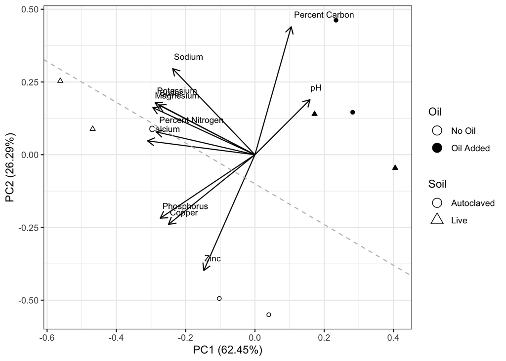

```r
df.pre <- subset(df, df$time=="pre-exp")

#PCA and plot pre-experiment only as biplot
#from https://towardsdatascience.com/principal-component-analysis-pca-101-using-r-361f4c53a9ff

df.PCA <- prcomp(df.pre[c(5:15)], center = TRUE, scale = TRUE)

p <- autoplot(df.PCA,
         data = df.pre,
         loadings = TRUE,
         loadings.colour = 'black',
         loadings.label.colour = 'black',
         loadings.label = TRUE,
         loadings.label.vjust = -1.5,
         loadings.label.hjust = -0.05,
         loadings.label.size = 3)
p$layers <- p$layers[-1]

pre <- p+ geom_point(mapping = SF1_aes) +
  my.scale_aes +
  geom_abline(intercept = -0.1, slope = -0.7, color="gray",
              linetype="dashed", size=0.5)

#print
pre
```

## Post-Experiment

Soil state at experiment harvest.

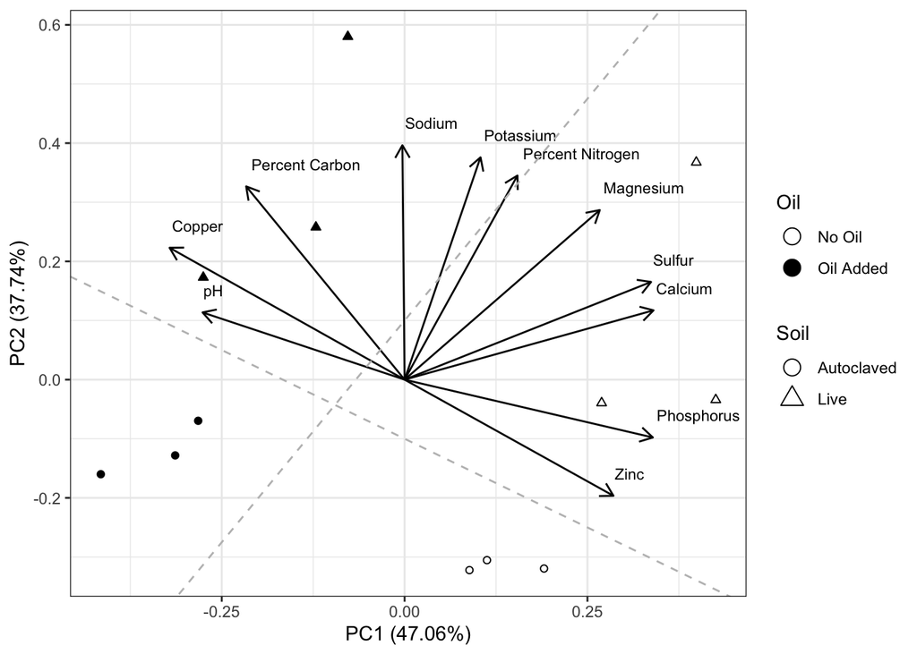

```r
df.post <- subset(df, df$time=="post-exp")

#PCA and plot post-experiment only as biplot
#from https://towardsdatascience.com/principal-component-analysis-pca-101-using-r-361f4c53a9ff

df.PCA <- prcomp(df.post[c(5:15)], center = TRUE, scale = TRUE)


p <- autoplot(df.PCA,
         data = df.post,
         loadings = TRUE,
         loadings.colour = 'black',
         loadings.label.colour = 'black',
         loadings.label = TRUE,
         loadings.label.vjust = -1.5,
         loadings.label.hjust = -0.05,
         loadings.label.size = 3)

p$layers <- p$layers[-1]

post <- p + geom_point(mapping = SF1_aes) +
  my.scale_aes +
  geom_abline(intercept = -0.1, slope = -0.6, color="gray",
              linetype="dashed", size=0.5) +
  geom_abline(intercept = 0.1, slope = 1.5, color="gray",
              linetype="dashed", size=0.5)

#print
post
```

## Plot Together

Plot pre- and post- experiment chemistry together

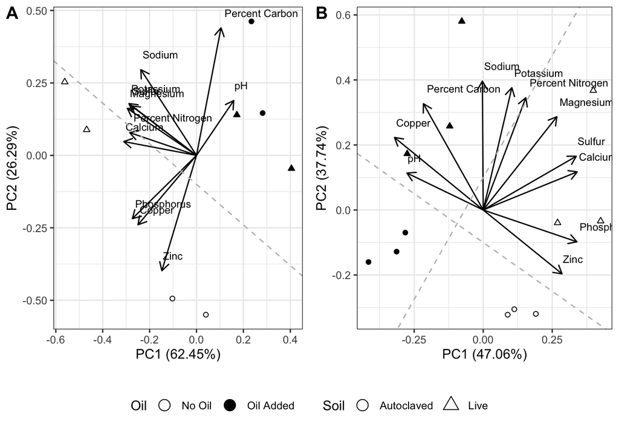

```r
top <- plot_grid(pre + theme(legend.position = "none"), post + theme(legend.position = "none"), ncol = 2, labels = "AUTO")

plot_grid(top, get_legend(post + theme(legend.position = "bottom")), ncol = 1, rel_heights = c(1,0.2))
```

## Relative abundance of chemistry

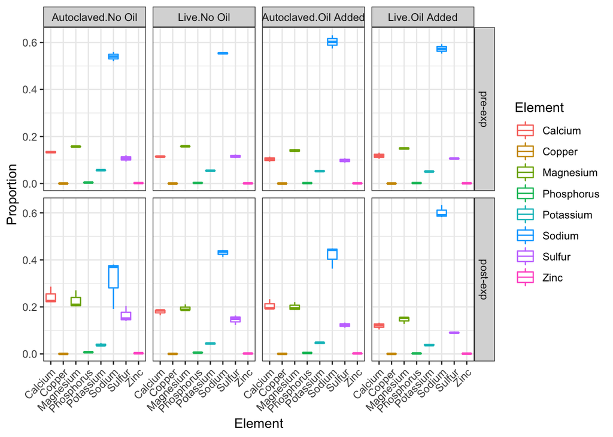

```r
#CLR Transformations

#This transforms each number into it's relative abundance in that sample
comps <- acomp(df[,c(5:7,9:13)])

RA.df <- cbind(comps, df)

RA.df.gathered <- RA.df %>%
  gather(key = "Element", value = "Proportion", c(1:8))

RA.df.gathered %>%
  ggplot(aes(x = Element,
             y = Proportion,
             color = Element)) +
  geom_boxplot() +
  facet_grid(rows = vars(time),
             cols = vars(interaction(soil,oil))) +
  theme_bw() +
  theme(axis.text.x = element_text(angle = 45, hjust = 1))
```

But as I understand it, it’s inappropriate to do the stats on this because it’s closed. Need to translate to CLR.

### Multivariate Methods

The central idea of the package following the coordinate approach of [Pawlowsky-Glahn(2003)] and [Pawlowsky-Glahn and Mateu-Figueras(2005)] is to transform the data by one of transforms into a classical multivariate dataset, to apply classical multivariate statistics and to back transform or interpreted the results afterwards in the original space.

According to https://www.rdocumentation.org/packages/rgr/versions/1.1.15/topics/clr all units should be the same, so the percents should be converted to ppm (or whatever is used).

*pH won’t be CLR transformed because it’s not compositional relative to the other elements (it covaries, but I don’t think that’s considered compositional).*

However, this paper (10.1007/s12665-019-8248-6) just used clr transformed pH , but its not clear what they used as the geometric mean.

## Aitchinson Distance of Chemistry

Re-analyze using Aitchison distance.

```r
#Convert %C and N to ppm
df$`Percent Carbon` <- df$`Percent Carbon`*10000
df$`Percent Nitrogen` <- df$`Percent Nitrogen`*10000

clr.df <- clr(df[,c(5:7,9:15)])

clr.df <- as.data.frame(clr.df)
clr.df$pH <- df$pH

pc <- princomp(x = clr.df)

pc$Loadings # The loadings as compositional vector
```

```r
pc$loadings # The loadings in clr-space
```

```
##
## Loadings:
##                  Comp.1 Comp.2 Comp.3 Comp.4 Comp.5 Comp.6 Comp.7 Comp.8 Comp.9
## Calcium           0.210                       0.118  0.127  0.266         0.526
## Copper           -0.483  0.135 -0.752  0.138  0.170         0.108  0.115
## Magnesium                       0.123         0.313  0.309  0.308         0.355
## Phosphorus        0.482 -0.114 -0.118  0.624 -0.208        -0.321  0.299
## Potassium        -0.239 -0.364        -0.110               -0.672 -0.437  0.209
## Sodium           -0.470 -0.368  0.363        -0.504         0.313  0.189
## Sulfur            0.114 -0.210  0.162 -0.290  0.497  0.184         0.294 -0.580
## Zinc              0.375        -0.334 -0.616 -0.485
## Percent Carbon   -0.175  0.714  0.335 -0.156        -0.131 -0.319  0.288
## Percent Nitrogen  0.125  0.228  0.147  0.200        -0.379  0.247 -0.667 -0.338
## pH                       0.290         0.190 -0.259  0.820        -0.226 -0.266
##                  Comp.10 Comp.11
## Calcium           0.686   0.316
## Copper                    0.316
## Magnesium        -0.672   0.316
## Phosphorus                0.316
## Potassium                 0.316
## Sodium                    0.316
## Sulfur            0.167   0.316
## Zinc             -0.142   0.316
## Percent Carbon            0.316
## Percent Nitrogen          0.316
## pH
##
##                Comp.1 Comp.2 Comp.3 Comp.4 Comp.5 Comp.6 Comp.7 Comp.8 Comp.9
## SS loadings     1.000  1.000  1.000  1.000  1.000  1.000  1.000  1.000  1.000
## Proportion Var  0.091  0.091  0.091  0.091  0.091  0.091  0.091  0.091  0.091
## Cumulative Var  0.091  0.182  0.273  0.364  0.455  0.545  0.636  0.727  0.818
##                Comp.10 Comp.11
## SS loadings      1.000   1.000
## Proportion Var   0.091   0.091
## Cumulative Var   0.909   1.000
```

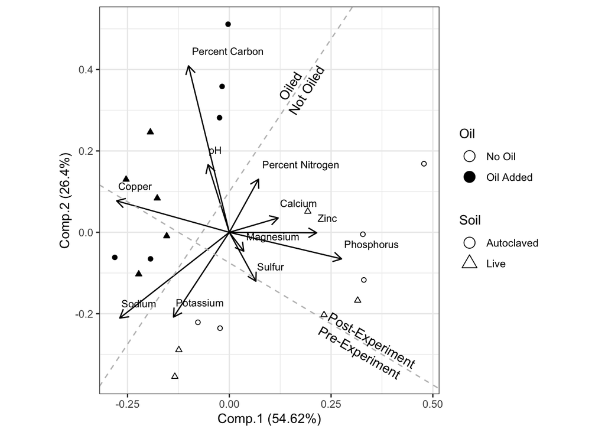

```r
df.pca <- pc$scores

aitchison.pca.plot <- cbind(na.omit(df), df.pca) %>%
  ggplot(aes(x = Comp.1,
             y = Comp.2)) +
  geom_point(mapping = SF1_aes) +
    facet_wrap(~ time) +
    my.scale_aes

p <- autoplot(pc,
         data = df,
         loadings = TRUE,
         loadings.colour = 'black',
         loadings.label.colour = 'black',
         loadings.label = TRUE,
         loadings.label.vjust = -1.5,
         loadings.label.hjust = -0.05,
         loadings.label.size = 3)

p$layers <- p$layers[-1]

#set aspect ratio for plotting labels

p + geom_point(mapping = SF1_aes) +
  my.scale_aes +
  geom_abline(intercept = -0.075, slope = -0.6, color="gray",
              linetype="dashed", size=0.5) +
  geom_abline(intercept = 0.1, slope = 1.5, color="gray",
              linetype="dashed", size=0.5) +
  coord_fixed() +
  geom_text(data=data.frame(x = 0.15,y = 0.36), aes(x, y), label="Oiled", hjust = 0.5, vjust=0.5, angle = 58) +
  geom_text(data=data.frame(x = 0.19,y = 0.35), aes(x, y), label="Not Oiled", hjust = 0.5, vjust=0.5, angle = 58) +
  geom_text(data=data.frame(x = 0.32,y = -0.295), aes(x, y), label="Pre-Experiment", hjust = 0.5, vjust=0.5, angle = -30) +
  geom_text(data=data.frame(x = 0.35,y = -0.265), aes(x, y), label="Post-Experiment", hjust = 0.5, vjust=0.5, angle = -30)
```

## PERMANOVA on Aitchinson distance

```r
df.clr <- cbind(df[,c(1:4)], clr.df)

set.seed(1)
adonis(formula = clr.df ~ soil*oil*time, data = df.clr, permutations = 9999, method = "euclidean")
```

```
##
## Call:
## adonis(formula = clr.df ~ soil * oil * time, data = df.clr, permutations = 9999,      method = "euclidean")
##
## Permutation: free
## Number of permutations: 9999
##
## Terms added sequentially (first to last)
##
##               Df SumsOfSqs MeanSqs F.Model      R2 Pr(>F)
## soil           1    2.0168  2.0168  10.600 0.09882 0.0001 ***
## oil            1    7.2494  7.2494  38.103 0.35522 0.0001 ***
## time           1    5.7570  5.7570  30.259 0.28209 0.0001 ***
## soil:oil       1    0.2016  0.2016   1.060 0.00988 0.3556
## soil:time      1    0.6301  0.6301   3.312 0.03087 0.0289 *
## oil:time       1    1.7716  1.7716   9.312 0.08681 0.0004 ***
## soil:oil:time  1    0.4986  0.4986   2.621 0.02443 0.0657 .
## Residuals     12    2.2831  0.1903         0.11187
## Total         19   20.4082                 1.00000
## ---
## Signif. codes:  0 '***' 0.001 '**' 0.01 '*' 0.05 '.' 0.1 ' ' 1
```

```r
elements <- df.clr %>%
  gather(key = "Element", value = "clr_val", Calcium:'Percent Nitrogen') %>%
  ggplot(aes(x = fct_reorder(Element, clr_val, .fun='median'),
         y = clr_val)) +
  geom_point(mapping = SF1_aes,
              size = 3,
             position = position_dodge(width = 0.5)) +
  my.scale_aes +
  theme_bw() +
  labs(y = "Centered Log-Ratio",
       x = NULL) +
  theme(axis.text.x = element_text(angle = 45, hjust = 1)) +
  facet_wrap(~ time)

pH <- df.clr %>%
  ggplot(aes(x = time,
         y = pH)) +
  geom_point(mapping = SF1_aes,
              size = 3,
             position = position_dodge(width = 0.5)) +
  my.scale_aes +
  theme_bw() +
  labs(y = "pH",
       x = NULL)
```

## Plot What is intended to be figure S1

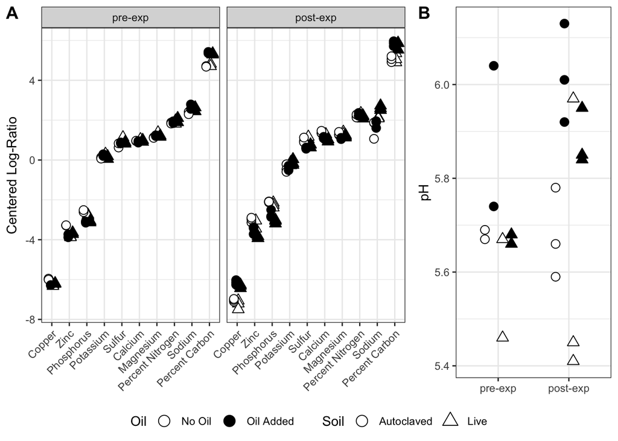

```r
top <- plot_grid(elements + theme(legend.position = "None"), pH + theme(legend.position = "None"), rel_widths = c(1,0.5), labels = "AUTO")

plot_grid(top, get_legend(pH + theme(legend.position = "bottom")), nrow = 2, rel_heights = c(1,0.1))
```